# Final Project: Modeling Project with Cars Data

Logan Hardy

4/18/2022

# Introduction

The data used in this study was obtained from Kaggle, an online data repository for users to easily share informative datasets with others. The link to this specific data is provided: https://www.kaggle.com/datasets/uciml/autompg-dataset. This dataset was originally published by the StatLib library, which is maintained by Carnegie Mellon University in July 1993.

Included is part of the path I took to clean, transform, and explore the data to discover intriguing findings and provide relevant recommendations.

# Data

The data I will be using comes from a mpg dataset

MPG - Vehicle’s miles-per-gallon average Cylinders - number of cylinders a vehicle has Displacement - Engine displacement/area Horse_Power - Vehicle’s horse power Weight - Weight of vehicle (lbs) Acceleration - avg time in seconds to accelate to 60 mph Model_year - year built Name - vehicle name

```r
# Load data and make copy
mpg <- read_csv("../Data/mpg.csv")
mpg_copy <- mpg
```

# Cleaning

I coerced cylinders to be an ordered factor and I eliminated columns/rows that were all NAs (data that’s not available).

```r
## Explore.2
# Coerce one variable into a more correct format.

# Coerce cylinders into ordered factor
mpg_copy <- mpg_copy %>% mutate(Cylinders = as.ordered(Cylinders))
summary(mpg_copy)
```

```
##       MPG        Cylinders  Displacement    Horse_Power        Weight
##  Min.   : 9.00   3:  4     Min.   : 68.0   Min.   : 46.0   Min.   :1613
##  1st Qu.:17.00   4:199     1st Qu.:105.0   1st Qu.: 75.0   1st Qu.:2225
##  Median :22.75   5:  3     Median :151.0   Median : 93.5   Median :2804
##  Mean   :23.45   6: 83     Mean   :194.4   Mean   :104.5   Mean   :2978
##  3rd Qu.:29.00   8:103     3rd Qu.:275.8   3rd Qu.:126.0   3rd Qu.:3615
##  Max.   :46.60             Max.   :455.0   Max.   :230.0   Max.   :5140
##   Acceleration     Model_Year        Name
##  Min.   : 8.00   Min.   :70.00   Length:392
##  1st Qu.:13.78   1st Qu.:73.00   Class :character
##  Median :15.50   Median :76.00   Mode  :character
##  Mean   :15.54   Mean   :75.98
##  3rd Qu.:17.02   3rd Qu.:79.00
##  Max.   :24.80   Max.   :82.00
```

```r
## Clean.1 & Transform.5
#Write one custom function and Use at least 2 of the NA techniques we learned

# Function to eliminate all NAs in a dataframe
eliminate_all_NAs <- function(df) {
  # Get rid of Columns that only have NAs / that are empty
  empty_columns <- colSums(is.na(df)) == nrow(df)
  df <- df[, !empty_columns]

  # Get rid of rows with NAs
  df <- df %>% na.omit()

  return(df)
}

# Call function to eliminate all NAs from dataframe
mpg_copy <- eliminate_all_NAs(mpg_copy)
```

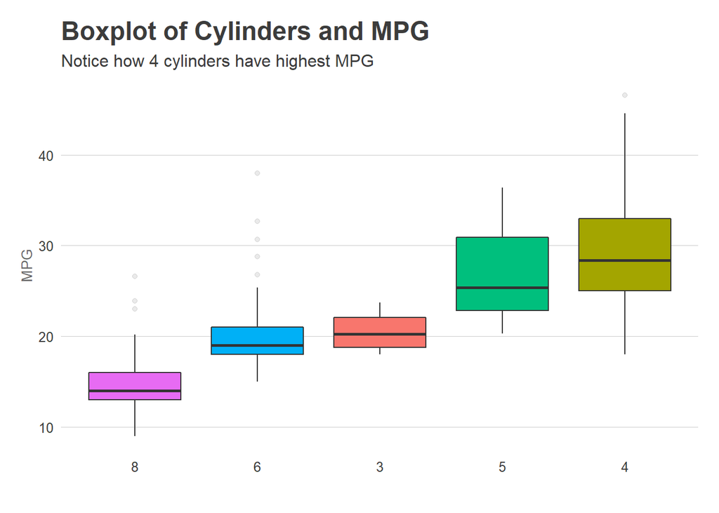

```r
## Transform 3
# You must provide well designed graphs of your data. Each must be well labeled and have some sort of default or custom theme applied.

mpg <- mpg %>% mutate(Cylinders = as.factor(Cylinders))

# Boxplot of pet lisence types
mpg %>%
        ggplot(aes(x = fct_reorder(Cylinders, MPG, median, na.rm = TRUE), y = MPG, fill = Cylinders)) +
        geom_boxplot(outlier.alpha = .1) +
        labs(title = "Boxplot of Cylinders and MPG",
            subtitle = "Notice how 4 cylinders have highest MPG",
            x = "") +
        theme_new +
        theme(axis.title = element_text(size = 10, color = "grey40"),
              axis.title.x = element_text(hjust = .02, vjust = .4),
              legend.position = "none")
```

```r
## Transform.6

# Find average/median numbers of MPG by cylinders
mpg %>% select(MPG, Cylinders) %>% group_by(Cylinders) %>% summarise(mean = mean(MPG), median = median(MPG))
```

```
## # A tibble: 5 x 3
##   Cylinders  mean median
##   <fct>     <dbl>  <dbl>
## 1 3          20.6   20.2
## 2 4          29.3   28.4
## 3 5          27.4   25.4
## 4 6          20.0   19
## 5 8          15.0   14
```

```r
## Transform 1&2
# Use the following functions - filter, mutate, select, summarize, group_by, arrange. (May be helpful after cleaning)

# Fiter
# Filter to see acceleration greater than 20
mpg_reduced <- mpg_copy %>% filter(Acceleration > 20)

# Mutate
# create new column that is the ratio of horse_power to displacement
mpg_copy <- mpg_copy %>% mutate(hp_per_displacement =
(Horse_Power /Displacement))
```

create linear models as a starting point Initial R-squared: 0.8142, Adjusted R-squared: 0.8108

```r
mpg_copy <- mpg_copy %>% select(-Name)
mpg_copy <- mpg_copy %>% mutate(Cylinders = as.numeric(Cylinders))
model <- lm(MPG~.,mpg_copy)
summary(model)
```

```
##
## Call:
## lm(formula = MPG ~ ., data = mpg_copy)
##
## Residuals:
##     Min      1Q  Median      3Q     Max
## -9.5272 -2.3509 -0.0636  2.1255 14.3475
##
## Coefficients:
##                       Estimate Std. Error t value Pr(>|t|)
## (Intercept)         -1.467e+01  5.483e+00  -2.676  0.00776 **
## Cylinders           -1.224e+00  3.832e-01  -3.194  0.00152 **
## Displacement         2.029e-02  1.055e-02   1.923  0.05519 .
## Horse_Power         -1.283e-02  2.000e-02  -0.641  0.52159
## Weight              -6.545e-03  6.659e-04  -9.828  < 2e-16 ***
## Acceleration         8.495e-02  1.029e-01   0.826  0.40944
## Model_Year           7.518e-01  5.284e-02  14.228  < 2e-16 ***
## hp_per_displacement  8.007e-01  2.763e+00   0.290  0.77212
## ---
## Signif. codes:  0 '***' 0.001 '**' 0.01 '*' 0.05 '.' 0.1 ' ' 1
##
## Residual standard error: 3.395 on 384 degrees of freedom
## Multiple R-squared:  0.8142, Adjusted R-squared:  0.8108
## F-statistic: 240.4 on 7 and 384 DF,  p-value: < 2.2e-16
```

```r
predicted <- predict(model)
actual <- mpg_copy$MPG

# cbind them together, then pipe into as_tibble(). Mutate the other columns, and save the dataset as model_accuracy.
model_accuracy <- cbind(predicted, actual) %>%
  as_tibble() %>%
  mutate(difference = predicted-actual,
         abs_difference = abs(difference),
         sqr_difference = difference*difference)

RMSE(predicted, actual)
```

```
## [1] 3.359848
```

```r
MAE(predicted, actual)
```

```
## [1] 2.566094
```

```r
normalize <- function(x) {
    return((x- min(x, na.rm = TRUE)) /(max(x, na.rm = TRUE)-min(x, na.rm = TRUE)))
}

min_max <- as.data.frame(lapply(mpg_copy, normalize))
model_min_max <- lm(MPG~.,min_max)
summary(model_min_max)
```

```
##
## Call:
## lm(formula = MPG ~ ., data = min_max)
##
## Residuals:
##      Min       1Q   Median       3Q      Max
## -0.25338 -0.06252 -0.00169  0.05653  0.38158
##
## Coefficients:
##                     Estimate Std. Error t value Pr(>|t|)
## (Intercept)          0.50197    0.04841  10.370  < 2e-16 ***
## Cylinders           -0.13021    0.04076  -3.194  0.00152 **
## Displacement         0.20885    0.10860   1.923  0.05519 .
## Horse_Power         -0.06277    0.09785  -0.641  0.52159
## Weight              -0.61395    0.06247  -9.828  < 2e-16 ***
## Acceleration         0.03796    0.04596   0.826  0.40944
## Model_Year           0.23995    0.01686  14.228  < 2e-16 ***
## hp_per_displacement  0.02429    0.08381   0.290  0.77212
## ---
## Signif. codes:  0 '***' 0.001 '**' 0.01 '*' 0.05 '.' 0.1 ' ' 1
##
## Residual standard error: 0.09028 on 384 degrees of freedom
## Multiple R-squared:  0.8142, Adjusted R-squared:  0.8108
## F-statistic: 240.4 on 7 and 384 DF,  p-value: < 2.2e-16
```

```r
# Split data into train and test groups

source("../Homework/Predict/preprocessing_functions.R")

set.seed(21)
sample <- trainIndex <- createDataPartition(mpg_copy$MPG, p = .85,
                                  list = FALSE,
                                  times = 1)
train <- mpg_copy[sample,]
test <- mpg_copy[-sample,]
```

```r
# Process train and test data (eliminated 4 columns)

train_processed <- train %>%
  remove_empty() %>%
  lump_factors(label = MPG, remove_label = FALSE) %>%
  impute() %>%
  remove_near_zero() %>%
  remove_linear_combos() %>%
  remove_correlated()

test_processed <- test %>%
  remove_empty() %>%
  lump_factors(label = MPG, remove_label = FALSE) %>%
  impute() %>%
  select(colnames(train_processed))
```

Supervised learning using neural networks Label = MPG

```r
# Lasso
model_lasso <- classification_train(train_processed, "MPG", method = "lasso")
```

```
## [1] "Model: lasso    RMSE: 0.64    MAE: 0.5    R-squared: 0.6   Time: 0.4"
```

```r
# Linear Regression
model_lm <- classification_train(train_processed, "MPG", method = "lm")
```

```
## [1] "Model: lm    RMSE: 0.63    MAE: 0.5    R-squared: 0.61   Time: 0.3"
```

```r
# Elasticnet
model_enet <- classification_train(train_processed, "MPG", method = "enet")
```

```
## [1] "Model: enet    RMSE: 0.64    MAE: 0.51    R-squared: 0.6   Time: 0.54"
```

```r
library(brnn)
library(neuralnet)

# brnn
model_brnn <- classification_train(train_processed, "MPG", method = "brnn")
```

[output not shown]

[output cut: 250 more lines]

[output not shown]

```r
# neuralnet
model_nn <- classification_train(train_processed, "MPG", method = "neuralnet")
```

```
## [1] "Model: neuralnet    RMSE: 0.6    MAE: 0.45    R-squared: 0.66   Time: 124.07"
```

```r
# Accuracy of lda model
predicted <- predict(model_lasso, test_processed)
print(paste0("RMSE: ", round(RMSE(predicted, test_processed$MPG), 3), "   MAE: ",
round(MAE(predicted, test_processed$MPG), 3)))
```

```
## [1] "RMSE: 0.682   MAE: 0.537"
```

```r
# Accuracy of random forest model
predicted <- predict(model_lm, test_processed)
print(paste0("RMSE: ", round(RMSE(predicted, test_processed$MPG), 3), "   MAE: ",
round(MAE(predicted, test_processed$MPG), 3)))
```

```
## [1] "RMSE: 0.678   MAE: 0.528"
```

```r
# Accuracy of svm model
predicted <- predict(model_enet, test_processed)
print(paste0("RMSE: ", round(RMSE(predicted, test_processed$MPG), 3), "   MAE: ",
round(MAE(predicted, test_processed$MPG ), 3)))
```

```
## [1] "RMSE: 0.679   MAE: 0.527"
```

```r
# Accuracy of lda model
predicted <- predict(model_brnn, test_processed)
print(paste0("RMSE: ", round(RMSE(predicted, test_processed$MPG), 3), "   MAE: ",
round(MAE(predicted, test_processed$MPG), 3)))
```

```
## [1] "RMSE: 0.611   MAE: 0.441"
```

```r
# Accuracy of random forest model
predicted <- predict(model_nn, test_processed)
print(paste0("RMSE: ", round(RMSE(predicted, test_processed$MPG), 3), "   MAE: ",
round(MAE(predicted, test_processed$MPG), 3)))
```

```
## [1] "RMSE: 0.639   MAE: 0.47"
```

```r
#create train and test data for categorization

train_processed <- train %>% dplyr::select(-Cylinders) %>%
  remove_empty(cutoff = 0.40) %>%
  impute(method = "median") %>%
  remove_near_zero(print_results = TRUE) %>%
  remove_linear_combos(print_results = TRUE) %>%
  remove_correlated(cutoff = 0.78, print_results = TRUE) %>%
  replace_label(train, Cylinders)
```

```
## [1] "Near Zero Variables: None"
## [1] "Linear Combos: None"
## [1] "Highly Correlated Variables: "
## [1] 2 4
```

```r
test_processed <- test %>% dplyr::select(-Cylinders) %>%
  remove_empty(cutoff = 0.40) %>%
  impute(method = "median") %>%
  remove_near_zero(print_results = TRUE) %>%
  replace_label(test, Cylinders) %>%
  dplyr::select(colnames(train_processed))
```

```
## [1] "Near Zero Variables: None"
```

Unsupervised learning using random forest 3 clusters

```r
library(randomForest)
library(pamr)

rf2 <- randomForest(x = mpg_copy, mtry = 3, ntree = 2000, proximity = TRUE)
rf2
```

```
##
## Call:
##  randomForest(x = mpg_copy, ntree = 2000, mtry = 3, proximity = TRUE)
##                Type of random forest: unsupervised
##                      Number of trees: 2000
## No. of variables tried at each split: 3
```

```r
prox <- rf2$proximity
pam.rf <- pam(prox, 3)
pred <- cbind(pam.rf$clustering, mpg_copy$Cylinders)
table(pred[,2], pred[,1])
```

```
##
##       1   2   3
##   1   0   4   0
##   2   0  58 141
##   3   0   3   0
##   4   0  83   0
##   5  94   9   0
```